# Arima_Model

By Sachin Janwalkar

# Load the dataset

```r
rm(list=ls())

library(tidyquant)
google_data <- getSymbols(Symbols = "GOOGL", src = "yahoo", from = "2000-01-01",
                        to = Sys.Date(), auto.assign = FALSE)
```

[output not shown]

```r
google_data <- Cl(google_data)
```

# STOCK CHARTING

In order to begin analysing stock, here’s the charting plus some technical indicators such as Simple Moving Average (20 and 100), Bollinger bands (20, sd = 1), Relative Strength Index (14 days), and Moving Average Convergence Divergence (12, 25) as the technical analysis before forecasting.

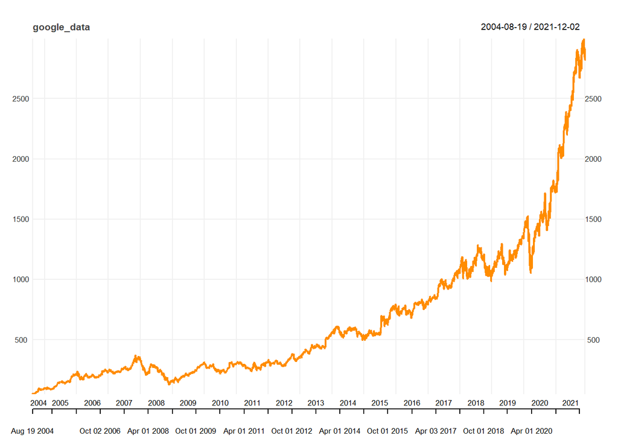

```r
chart_Series(google_data, col = "black")
```

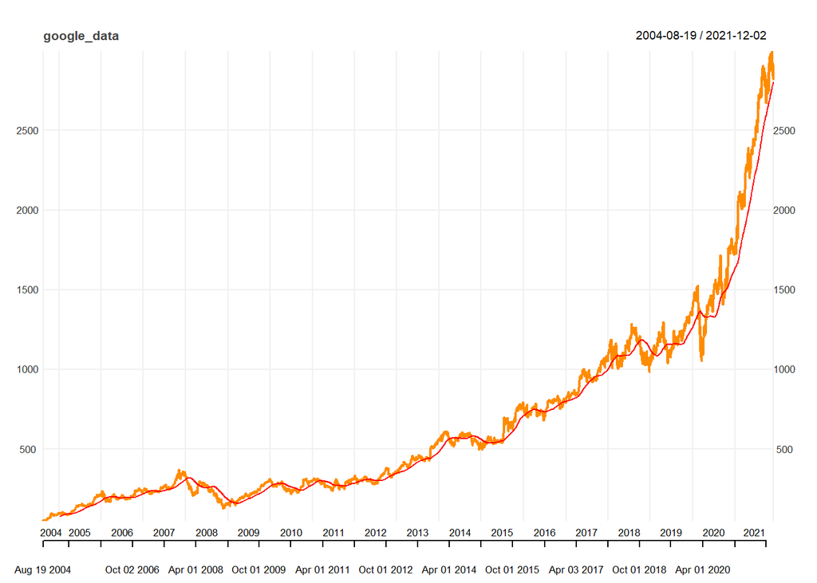

```r
add_SMA(n = 100, on = 1, col = "red")
```

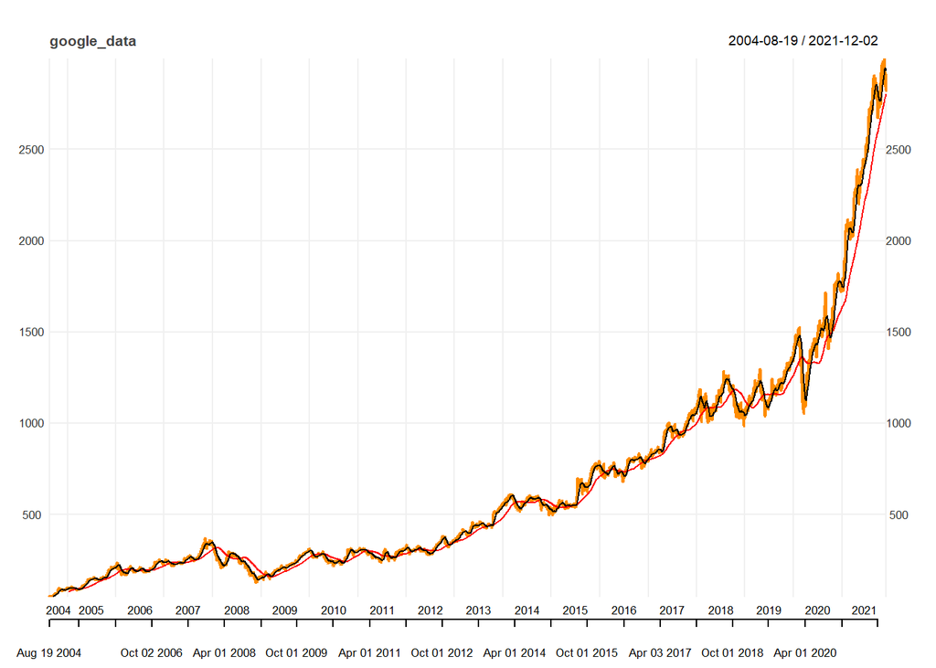

```r
add_SMA(n = 20, on = 1, col = "black")
```

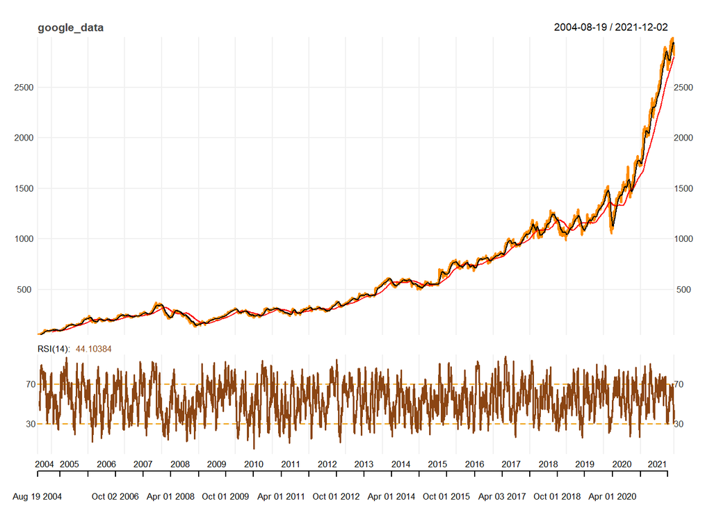

```r
add_RSI(n = 14, maType = "SMA")
```

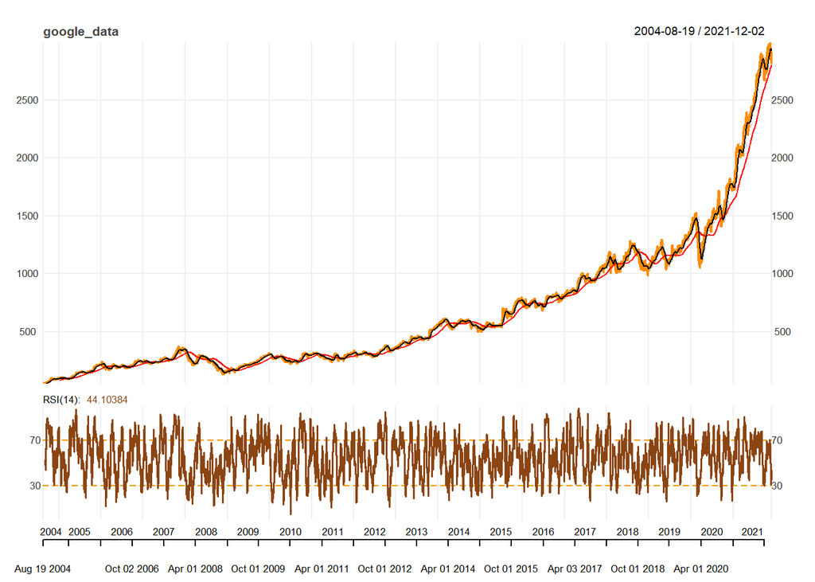

```r
add_BBands(n = 20, maType = "SMA", sd = 1, on = -1)
```

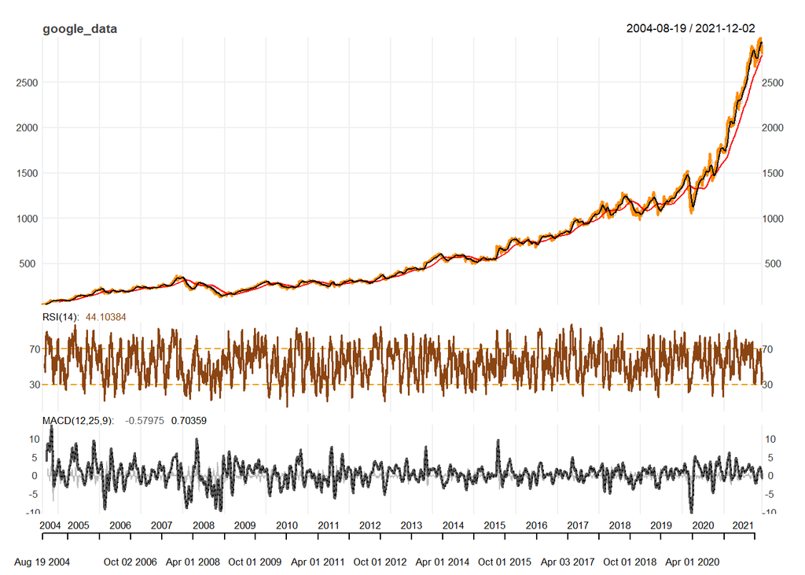

```r
add_MACD(fast = 12, slow = 25, signal = 9, maType = "SMA", histogram = TRUE)
```

# Checking whether data is Stationary or Not

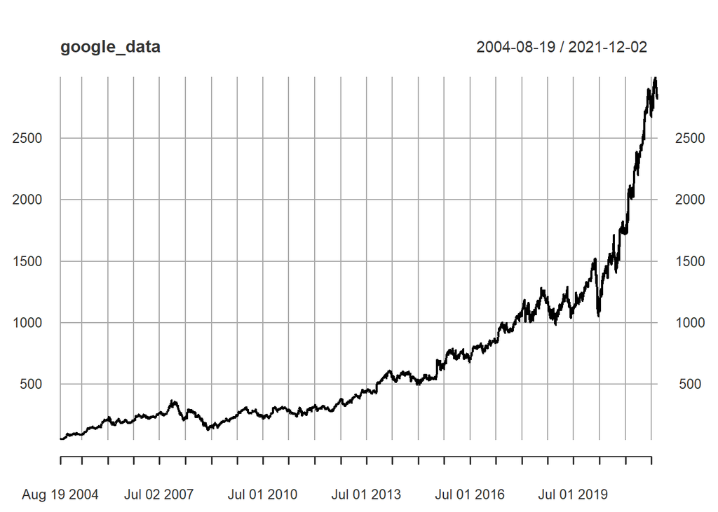

```r
plot(google_data)
```

# Transforming the data with Log

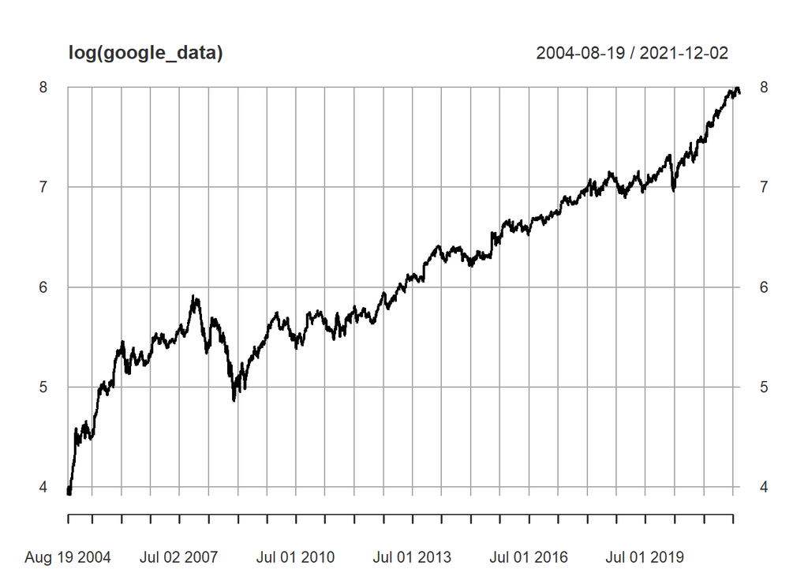

```r
plot(log(google_data))
```

As the data has been log-transformed, we can clearly see that the series shows some upward and downward trend in a given time interval. Through out the year of Aug 2004 to April 2008, the stock showed upward trend, immediately after April it shows downward trend then rising continuously afterwards. The stock also consist of some volatility and swing. These are the signs that the stock price movement is non-stationary. Matter of fact, most of financial data is non-stationary (in which the mean, variance, autocorrelation, are not constant over time), but most of them follow random walk model with or without drift (RWM or RWD), This is due to the stock tend to having trend and inconstant variance and mean in a given period. Given that we can guess that its a random walk, which means the current value (price) is equal to its price at time (t - 1) plus a random shock (White Noise), hence we should difference the data with certain lag in order to fit ARIMA model as we’ll see later

# Checking the Autocorrelation and Partial Autocorrelation Function

This is where we check whether the current value is correlated to the past/yesterdays value.

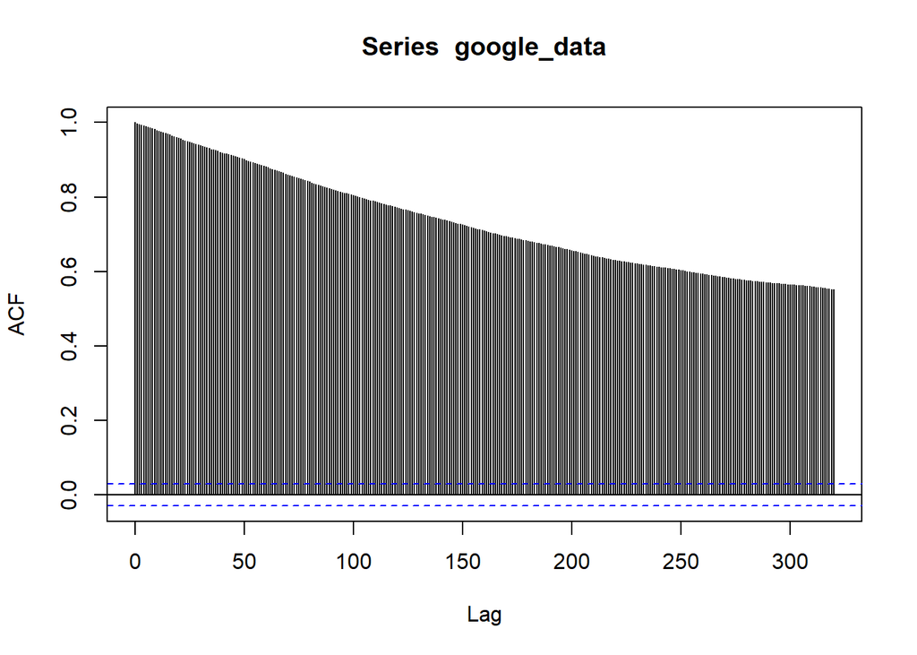

```r
acf_google = acf(google_data, lag.max = 320)
```

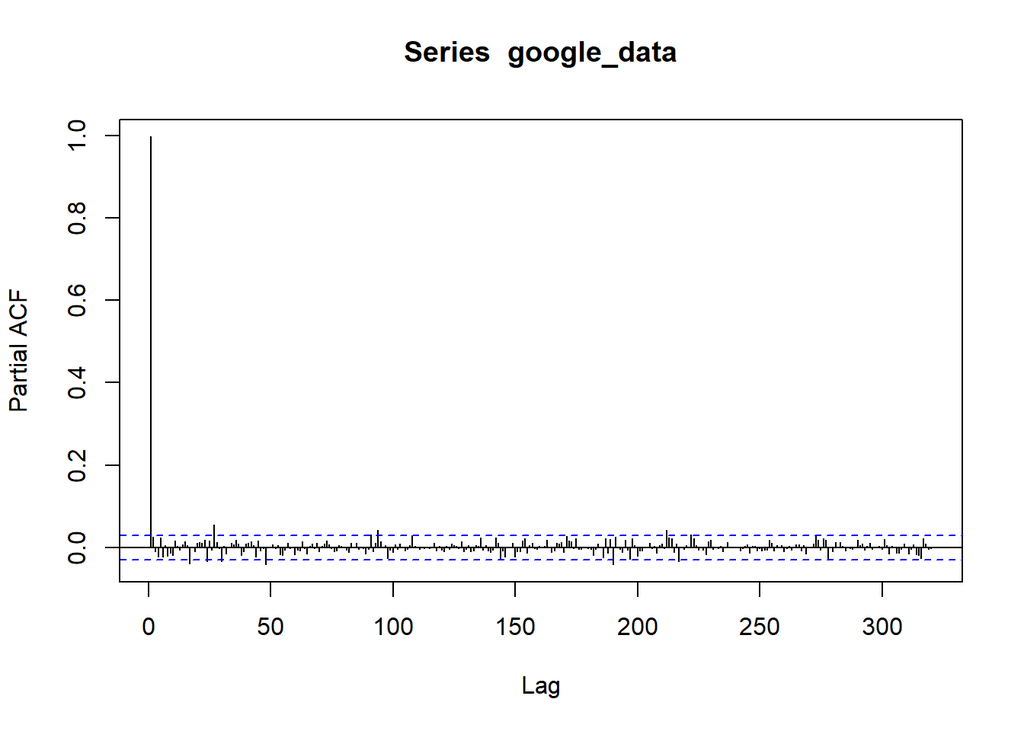

```r
pacf_google=pacf(google_data, lag.max = 320)
```

TO make our data stationary we should differenciate it to adjust the mean component i.e. all mean are equal

# Making the Data Stationary

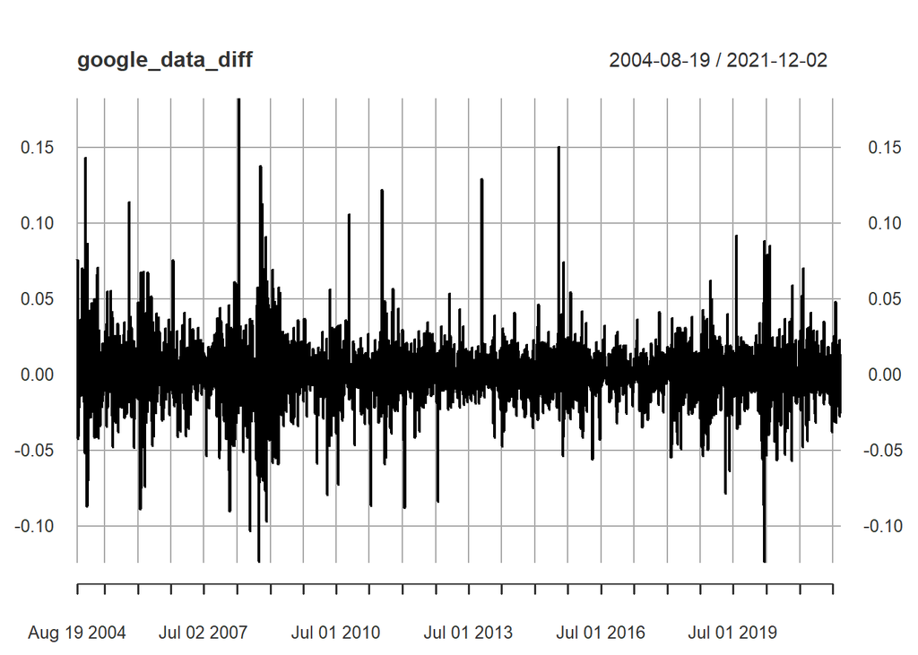

```r
google_data_diff= diff(log(google_data), lag =1) # Adjusting the mean

google_data_diff = na.locf(google_data_diff, na.rm = TRUE,
                      fromLast = TRUE) # Replacing missing values

plot(google_data_diff)
```

# Testing the Stationarity using Augmented Dickey Fuller Test. Null Hypothesis = Non-Satationary Alternative Hyp = Stationary

```r
library(tseries)
adf <- adf.test(google_data, alternative = c("stationary", "explosive"),
                k = 0)
adf
```

```
##
##  Augmented Dickey-Fuller Test
##
## data:  google_data
## Dickey-Fuller = 1.4024, Lag order = 0, p-value = 0.99
## alternative hypothesis: stationary
```

Hence as p-value>0.05, we cannot RJ null and conclude that our undifferentiated google stock data is non-Stationary.

```r
adf <- adf.test(google_data_diff, alternative = c("stationary", "explosive"),
                k = 0)
adf
```

```
##
##  Augmented Dickey-Fuller Test
##
## data:  google_data_diff
## Dickey-Fuller = -67.4, Lag order = 0, p-value = 0.01
## alternative hypothesis: stationary
```

AS the p-value<0.05, we can reject null and conclude that our differenciated google stock data is stationary.

# Plotting ACF and PACF Curves

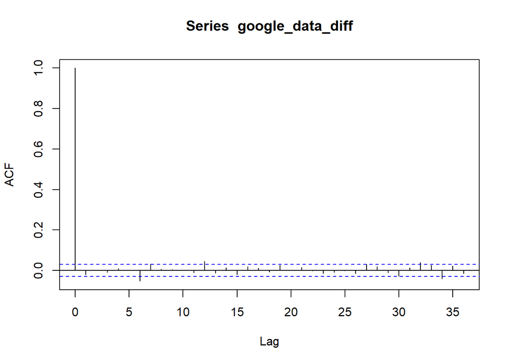

```r
acf_google  = acf(google_data_diff) # Determining the value of autoregressive AR(P)
```

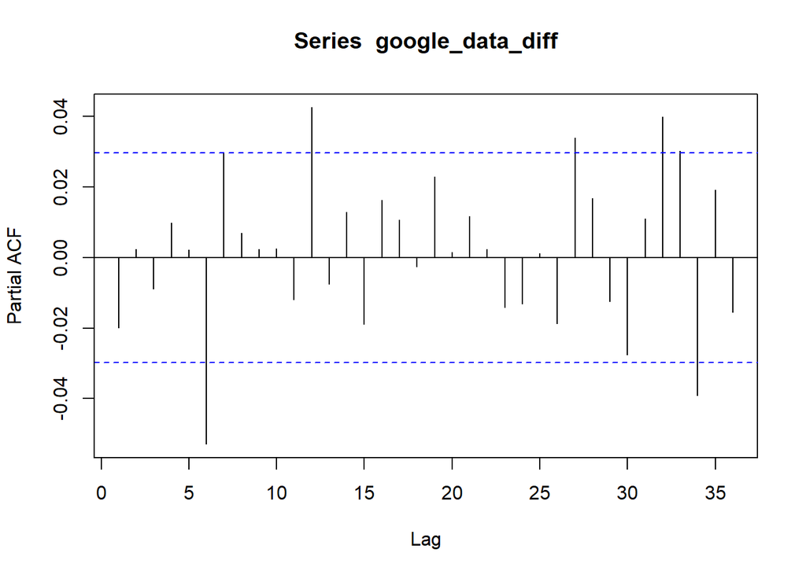

```r
pacf_google = pacf(google_data_diff) # Determining the value of moving avg MA(p)
```

# Build the ARIMA Model

```r
library(forecast)
set.seed(100)
arima_model <- auto.arima(google_data_diff, stationary = TRUE, ic = c("aicc", "aic", "bic"),
                          trace = TRUE)
```

```
##
##  Fitting models using approximations to speed things up...
##
##  ARIMA(2,0,2) with non-zero mean : -22197.49
##  ARIMA(0,0,0) with non-zero mean : -22167.91
##  ARIMA(1,0,0) with non-zero mean : -22182.5
##  ARIMA(0,0,1) with non-zero mean : -22167.62
##  ARIMA(0,0,0) with zero mean     : -22159.1
##  ARIMA(1,0,2) with non-zero mean : -22188.81
##  ARIMA(2,0,1) with non-zero mean : -22194.29
##  ARIMA(3,0,2) with non-zero mean : -22199.8
##  ARIMA(3,0,1) with non-zero mean : -22192.59
##  ARIMA(4,0,2) with non-zero mean : -22201.26
##  ARIMA(4,0,1) with non-zero mean : -22194.38
##  ARIMA(5,0,2) with non-zero mean : -22198.99
##  ARIMA(4,0,3) with non-zero mean : -22198.98
##  ARIMA(3,0,3) with non-zero mean : -22197.95
##  ARIMA(5,0,1) with non-zero mean : Inf
##  ARIMA(5,0,3) with non-zero mean : -22197.5
##  ARIMA(4,0,2) with zero mean     : -22192.93
##
##  Now re-fitting the best model(s) without approximations...
##
##  ARIMA(4,0,2) with non-zero mean : -22172.99
##
##  Best model: ARIMA(4,0,2) with non-zero mean
```

```r
summary(arima_model)
```

```
## Series: google_data_diff
## ARIMA(4,0,2) with non-zero mean
##
## Coefficients:
##           ar1      ar2      ar3     ar4      ma1     ma2   mean
##       -0.0089  -0.9311  -0.0152  0.0230  -0.0109  0.9366  9e-04
## s.e.   0.0788   0.0363   0.0187  0.0165   0.0776  0.0343  3e-04
##
## sigma^2 estimated as 0.0003589:  log likelihood=11094.51
## AIC=-22173.03   AICc=-22172.99   BIC=-22122
##
## Training set error measures:
##                        ME       RMSE        MAE  MPE MAPE      MASE
## Training set 6.344033e-05 0.01892889 0.01271198 -Inf  Inf 0.6843222
##                      ACF1
## Training set 0.0002507685
```

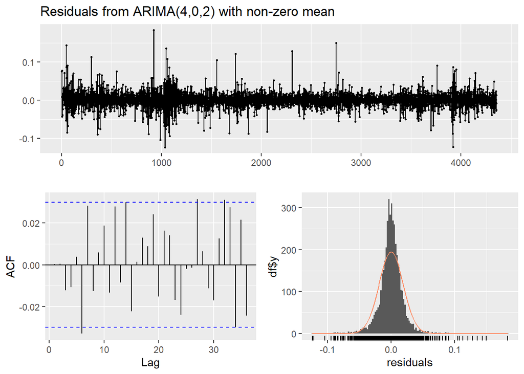

```
##
##  Ljung-Box test
##
## data:  Residuals from ARIMA(4,0,2) with non-zero mean
## Q* = 11.675, df = 3, p-value = 0.008585
##
## Model df: 7.   Total lags used: 10
```

```r
checkresiduals(arima_model) ###diagnostic cheking
```

# Fitting the model and forecasting

```r
arima <- arima(google_data_diff, order = c(4, 0, 2))
summary(arima)
```

```
##
## Call:
## arima(x = google_data_diff, order = c(4, 0, 2))
##
## Coefficients:
##           ar1      ar2      ar3     ar4      ma1     ma2  intercept
##       -0.0089  -0.9311  -0.0152  0.0230  -0.0109  0.9366      9e-04
## s.e.   0.0788   0.0363   0.0187  0.0165   0.0776  0.0343      3e-04
##
## sigma^2 estimated as 0.0003583:  log likelihood = 11094.51,  aic = -22173.03
##
## Training set error measures:
##                        ME       RMSE        MAE  MPE MAPE      MASE
## Training set 6.344033e-05 0.01892889 0.01271198 -Inf  Inf 0.6843222
##                      ACF1
## Training set 0.0002507685
```

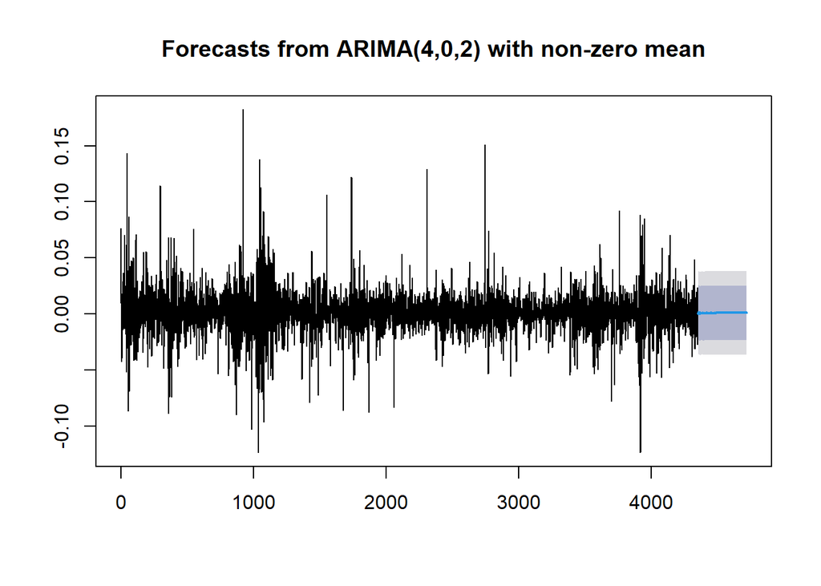

```r
forecast_google <- forecast(arima, h = 365)
plot(forecast_google)
```

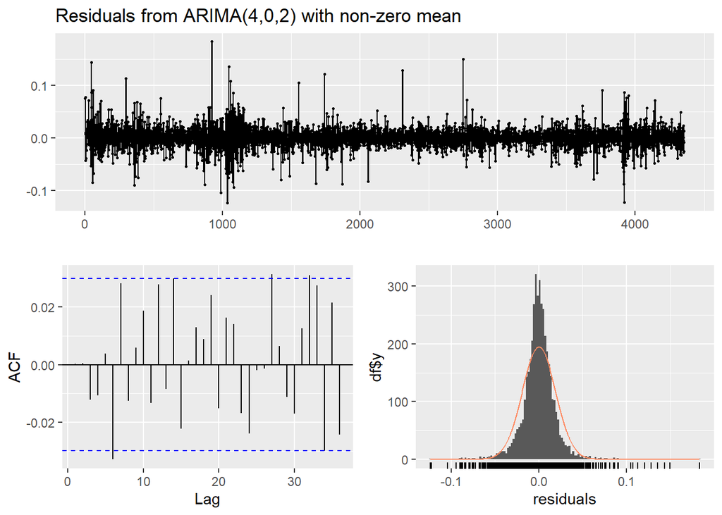

```
##
##  Ljung-Box test
##
## data:  Residuals from ARIMA(4,0,2) with non-zero mean
## Q* = 11.675, df = 3, p-value = 0.008585
##
## Model df: 7.   Total lags used: 10
```

```r
checkresiduals(arima)
```

```r
arima1 = arima(log(google_data[1:3800]), order=c(4,1,2))
summary(arima1)
```

```
##
## Call:
## arima(x = log(google_data[1:3800]), order = c(4, 1, 2))
##
## Coefficients:
##          ar1      ar2     ar3     ar4     ma1     ma2
##       0.0012  -0.9437  0.0119  0.0089  0.0104  0.9347
## s.e.  0.0732   0.0338  0.0197  0.0169  0.0715  0.0300
##
## sigma^2 estimated as 0.0003547:  log likelihood = 9699.5,  aic = -19384.99
##
## Training set error measures:
##                        ME       RMSE        MAE        MPE      MAPE     MASE
## Training set 0.0008333542 0.01883115 0.01264983 0.01497678 0.2223429 1.001872
##                      ACF1
## Training set -0.001867811
```

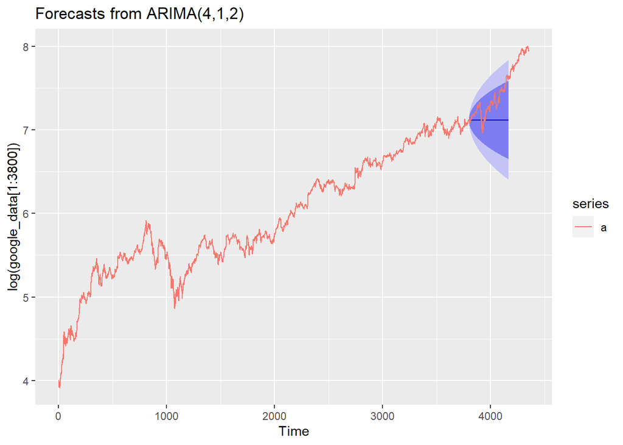

```r
forecast_1=forecast(arima1, h=365)
a = ts(log(google_data))
forecast_1 %>% autoplot()+autolayer(a)
```

# Learning Outcome:

Sometimes forecasting time series is difficult, in a way that the forecaster should have some specific domain knowledges and skill plus often times we could encounter model that seems appropriate but cannot capture the data movement, and vice versa. If arima does not yield good result, that means the data has some characteristic that arima could not capture. Hence we can try using other time series models such as VAR, GARCH (volatiliry clustering), or even the sophisticated Fourier transformation model, depends on the data characteristics. Thus forecasting should not be taken as a fixed result, but instead interative process until we can find the perfect model that could predict the movement of financial data.